# Tidyverse: Visualizing Data (ggplot2)

### Exercise

The `mpg` file comes with the ggplot2 package. It contains data about fuel economy of different cars.

```r
mpg
```

| manufacturer | model | displ | year | cyl | trans | drv | cty | hwy | fl | class |
| --- | --- | --- | --- | --- | --- | --- | --- | --- | --- | --- |
| audi | a4 | 1.8 | 1999 | 4 | auto(l5) | f | 18 | 29 | p | compact |
| audi | a4 | 1.8 | 1999 | 4 | manual(m5) | f | 21 | 29 | p | compact |
| audi | a4 | 2.0 | 2008 | 4 | manual(m6) | f | 20 | 31 | p | compact |
| audi | a4 | 2.0 | 2008 | 4 | auto(av) | f | 21 | 30 | p | compact |
| audi | a4 | 2.8 | 1999 | 6 | auto(l5) | f | 16 | 26 | p | compact |
| audi | a4 | 2.8 | 1999 | 6 | manual(m5) | f | 18 | 26 | p | compact |
| audi | a4 | 3.1 | 2008 | 6 | auto(av) | f | 18 | 27 | p | compact |
| audi | a4 quattro | 1.8 | 1999 | 4 | manual(m5) | 4 | 18 | 26 | p | compact |
| audi | a4 quattro | 1.8 | 1999 | 4 | auto(l5) | 4 | 16 | 25 | p | compact |
| audi | a4 quattro | 2.0 | 2008 | 4 | manual(m6) | 4 | 20 | 28 | p | compact |

[output cut: 224 more lines]

- `displ` engine displacement, in liters
- `hwy` highway miles per gallon
- `drv` the type of drive train, where f = front-wheel drive, r = rear wheel drive, 4 = 4wd

Create a scatterplot with the displacement on the x axis, highway miles per gallon on the y axis, and the type of drive train as the color legend.

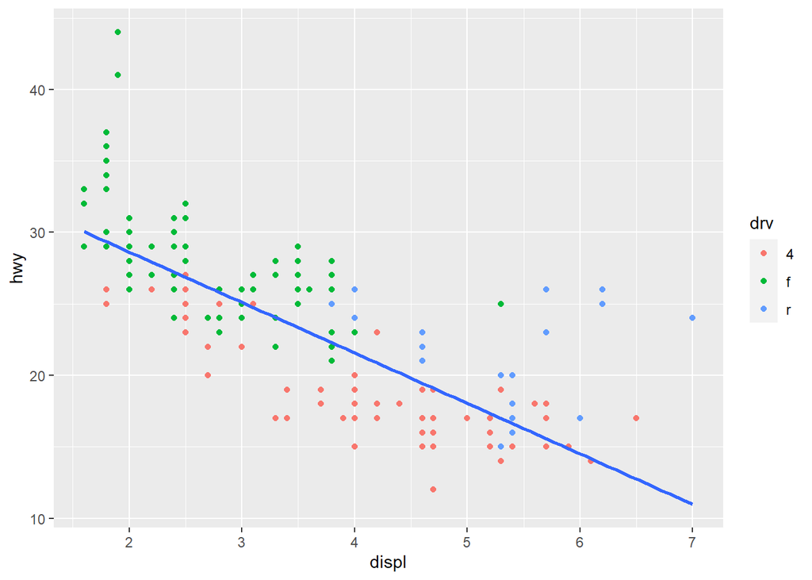

```r
## answer here
ggplot(mpg, aes(x = displ, y = hwy))+
    geom_point(aes(color = drv))+
    geom_smooth(method = "lm",
                se = F)
```

## Line Charts

Recall, line charts are commonly used to visualize trend over time. Therefore, it is important that know how to manipulate dates suitable for a ggplot line chart. Suppose the `airquality` data which contains air quality measurements in New York in 1973.

```r
airquality
```

| Ozone | Solar.R | Wind | Temp | Month | Day |
| --- | --- | --- | --- | --- | --- |
| 41 | 190 | 7.4 | 67 | 5 | 1 |
| 36 | 118 | 8.0 | 72 | 5 | 2 |
| 12 | 149 | 12.6 | 74 | 5 | 3 |
| 18 | 313 | 11.5 | 62 | 5 | 4 |
| NA | NA | 14.3 | 56 | 5 | 5 |
| 28 | NA | 14.9 | 66 | 5 | 6 |
| 23 | 299 | 8.6 | 65 | 5 | 7 |
| 19 | 99 | 13.8 | 59 | 5 | 8 |
| 8 | 19 | 20.1 | 61 | 5 | 9 |
| NA | 194 | 8.6 | 69 | 5 | 10 |

[output cut: 143 more lines]

We add a `Date` column. The function `make_date` is in the `lubridate` package. If we have a proper `Date` column, manipulation and visualization will be more intuitive.

```r
library(lubridate)
airquality %>%
  mutate(Date = make_date(year = 1973,
                          month = Month,
                          day = Day)
         )%>% select(c(Temp, Date))
```

| Temp | Date |
| --- | --- |
| 67 | 1973-05-01 |
| 72 | 1973-05-02 |
| 74 | 1973-05-03 |
| 62 | 1973-05-04 |
| 56 | 1973-05-05 |
| 66 | 1973-05-06 |
| 65 | 1973-05-07 |
| 59 | 1973-05-08 |
| 61 | 1973-05-09 |
| 69 | 1973-05-10 |

[output cut: 143 more lines]

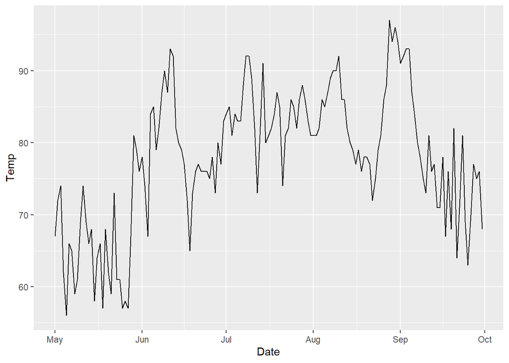

```r
airquality %>%
  mutate(Date = make_date(year = 1973,
                          month = Month,
                          day = Day)
         ) %>%
  ggplot(aes(x = Date, y = Temp)) +
  geom_line()
```

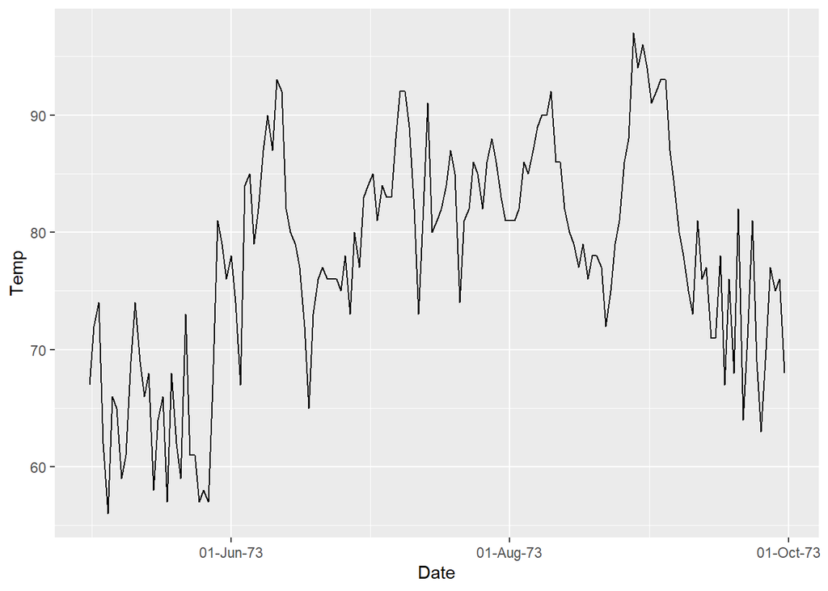

```r
airquality %>%
  mutate(Date = make_date(year = 1973,
                          month = Month,
                          day = Day)
         ) %>%
  ggplot(aes(x = Date, y = Temp)) +
  geom_line()+
    scale_x_date(date_breaks = "2 months", date_labels = "%d-%b-%y")
```

### Exercise

The `Orange`dataset contains measurements of the growth of orange trees over time.

```r
Orange
```

|  | Tree | age | circumference |
| --- | --- | --- | --- |
| 1 | 1 | 118 | 30 |
| 2 | 1 | 484 | 58 |
| 3 | 1 | 664 | 87 |
| 4 | 1 | 1004 | 115 |
| 5 | 1 | 1231 | 120 |
| 6 | 1 | 1372 | 142 |
| 7 | 1 | 1582 | 145 |
| 8 | 2 | 118 | 33 |
| 9 | 2 | 484 | 69 |
| 10 | 2 | 664 | 111 |

[output cut: 25 more lines]

The `Tree` column is an ordered factor, but the order is not intuitive. We reorder the levels using the following chunk.

```r
Orange$Tree <- ordered(Orange$Tree, levels = c(5,4,3,2,1))
levels(Orange$Tree)
```

```
## [1] "5" "4" "3" "2" "1"
```

Now, create a line chart with **`age`** on the x axis, `circumference` on the y axis, and the `Tree` group as color legend.

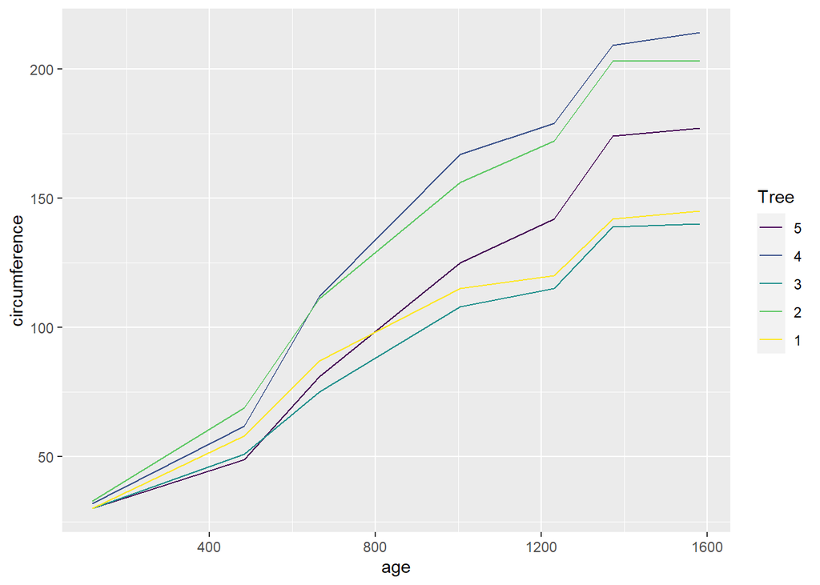

```r
## type your answer here!
ggplot(Orange, aes(x = age, y = circumference))+
    geom_line(aes(color = Tree))
```

## Histogram and Density Plots

Initializing a dataset.

```r
set.seed(125)
norm1 <- rnorm(100, mean = 1, sd = 3)
norm2 <- rnorm(100, mean = 8, sd = 2)
norm3 <- rnorm(100, mean = 15, sd = 3)
norm.dat <- data.frame(norm1, norm2, norm3) %>%
    pivot_longer(cols = c("norm1", "norm2", "norm3"))
```

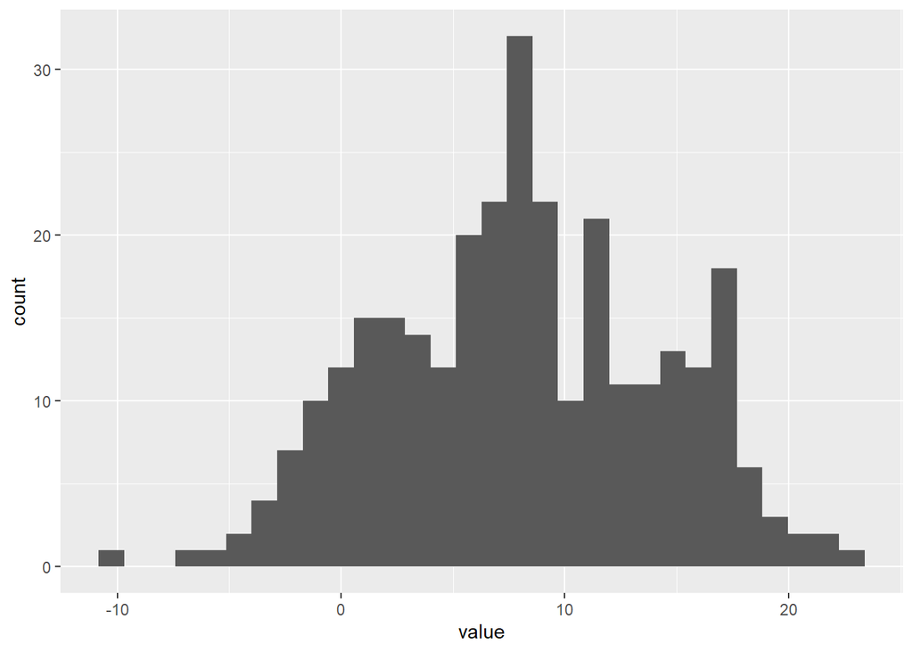

```r
## Type in this chunk when following the codes on the screen
ggplot(norm.dat, aes(x = value))+
    geom_histogram()
```

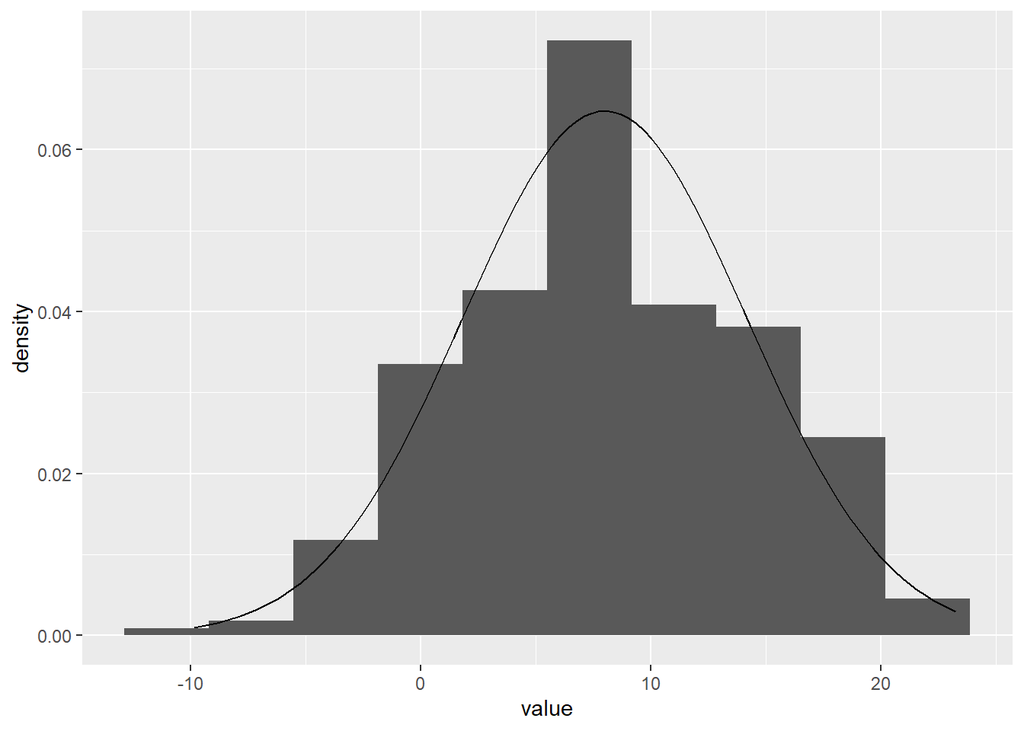

```r
# final code
ggplot(norm.dat, aes(x = value))+
    geom_histogram(aes(y = ..density..), bins = 10)+
    stat_function(fun = dnorm,
                  args = list(
                      mean = mean(norm.dat$value),
                      sd = sd(norm.dat$value)))
```

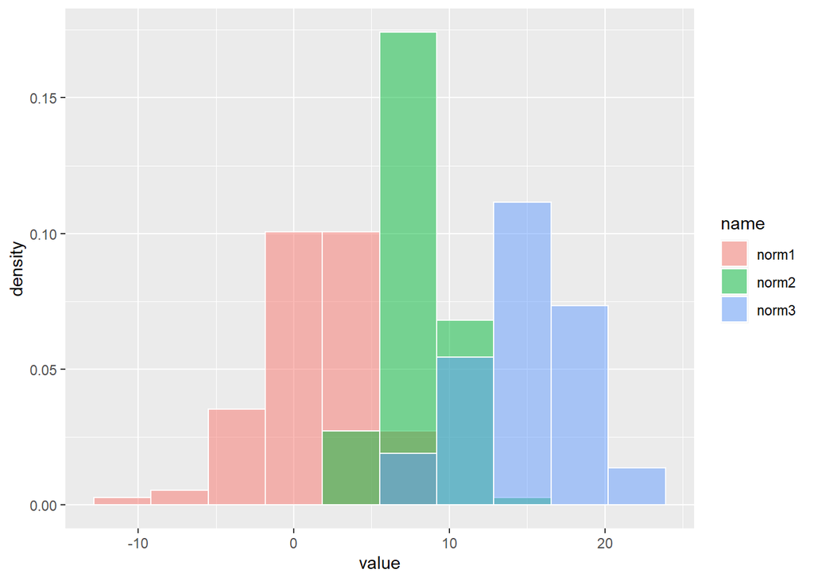

```r
ggplot(norm.dat, aes(x = value,
                     fill = name))+
    geom_histogram(bins = 10,
                   position = "identity",
                   alpha = 0.5,
                   color = "white",
                   aes(y = ..density..))
```

## Boxplots

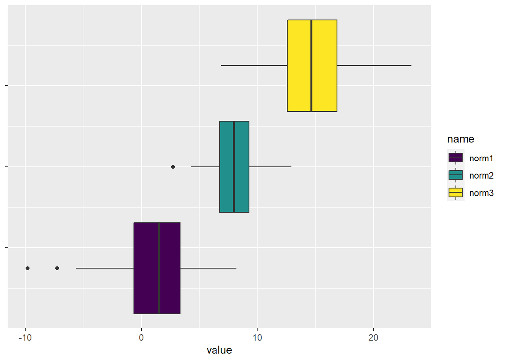

```r
ggplot(norm.dat, aes(x = value, fill = name))+
    geom_boxplot()+
    scale_fill_viridis_d()+
    theme(axis.text.y=element_blank())
```

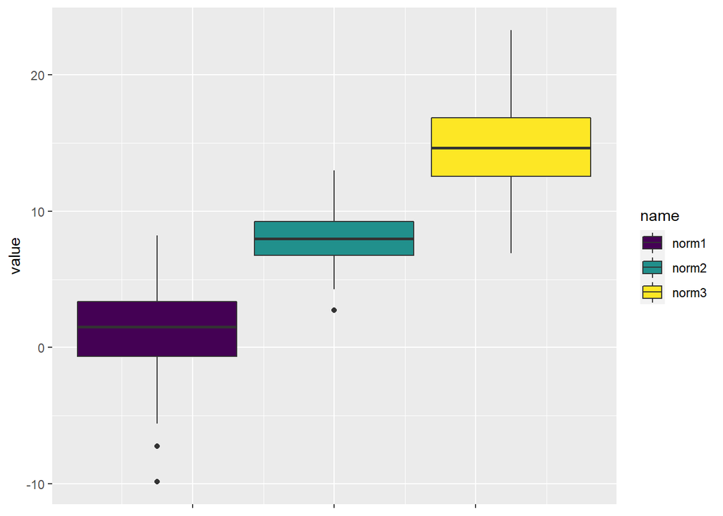

```r
ggplot(norm.dat, aes(y = value, fill = name))+
    geom_boxplot()+
    scale_fill_viridis_d()+
    theme(axis.text.x=element_blank())
```

## Bar Chart and Variations

For this part, let’s use the `satisfaction` data

```r
satisfaction <- read_csv("employee satisfaction.csv")
satisfaction
```

| emp_id | age | birthdate | sex | daily_rate | department | work_tenure | work_life | relationship | job_role |
| --- | --- | --- | --- | --- | --- | --- | --- | --- | --- |
| emp1417 | 36 | 10/16/1985 | Male | PHP600.00 | Research & Development | 1 | Dissatisfied | Dissatisfied | Satisfied |
| emp2884 | 40 | 10/17/1981 | Female | PHP900.00 | Sales | 2 | Neutral | Very Dissatisfied | Satisfied |
| emp540 | 24 | 10/13/1997 | Male | PHP400.00 | Research & Development | 1 | Neutral | Very Dissatisfied | Neutral |
| emp2850 | 32 | 10/15/1989 | Male | PHP400.00 | Research & Development | 6 | Neutral | Neutral | Dissatisfied |
| emp3520 | 30 | 10/15/1991 | Female | PHP400.00 | Research & Development | 1 | Satisfied | Neutral | Dissatisfied |
| emp3682 | 50 | 10/20/1971 | Male | PHP600.00 | Research & Development | 0 | Dissatisfied | Neutral | Neutral |
| emp2855 | 42 | 10/18/1979 | Male | PHP500.00 | Sales | 3 | Neutral | Satisfied | Very Dissatisfied |
| emp811 | 38 | 10/17/1983 | Male | PHP1,300.00 | Research & Development | 10 | Neutral | Very Dissatisfied | Very Dissatisfied |
| emp2723 | 40 | 10/17/1981 | Male | PHP1,500.00 | Sales | 12 | Neutral | Satisfied | Satisfied |
| emp3662 | 38 | 10/17/1983 | Male | PHP1,000.00 | Research & Development | 6 | Neutral | Neutral | Neutral |

[output cut: 2490 more lines]

**Version 1**: 1 chart, same y axis for all.

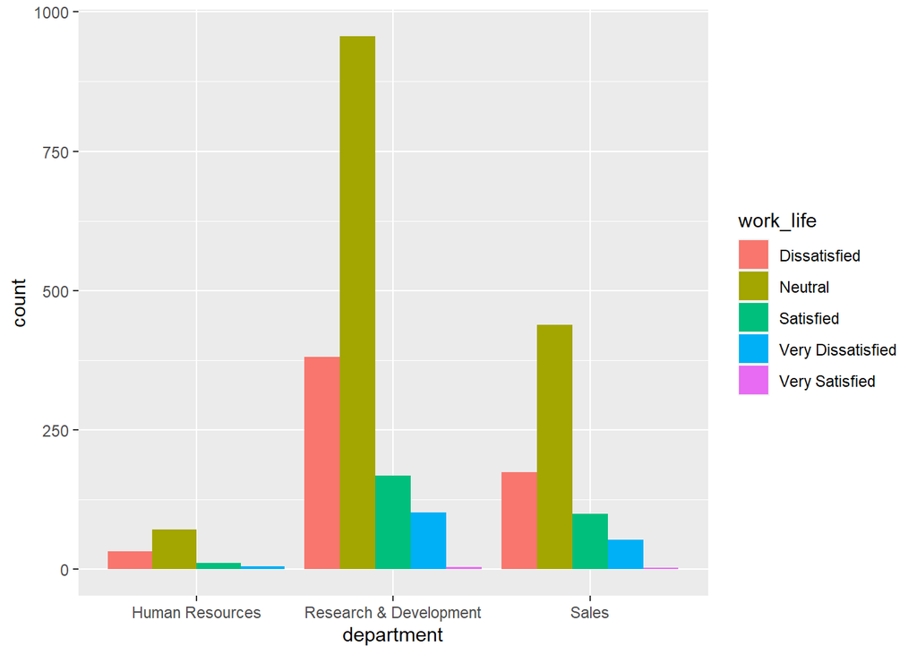

```r
ggplot(satisfaction,
       aes(x = department)) +
  geom_bar(aes(fill = work_life),
           stat = "count",
           position = "dodge")
```

**Version 2**: Different charts, different y axes.

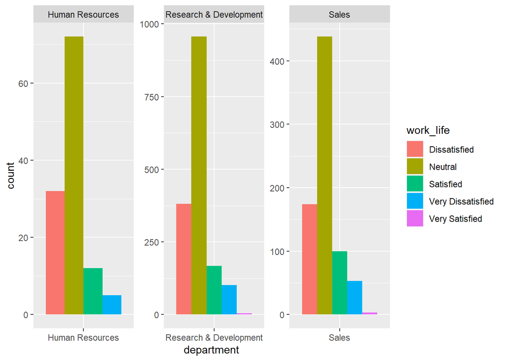

```r
ggplot(satisfaction,
       aes(x = department)) +
  geom_bar(aes(fill = work_life),
           stat = "count",
           position = "dodge") +
  facet_wrap(. ~ department, scale = "free")
```

**Version 3:** Stacked bar chart

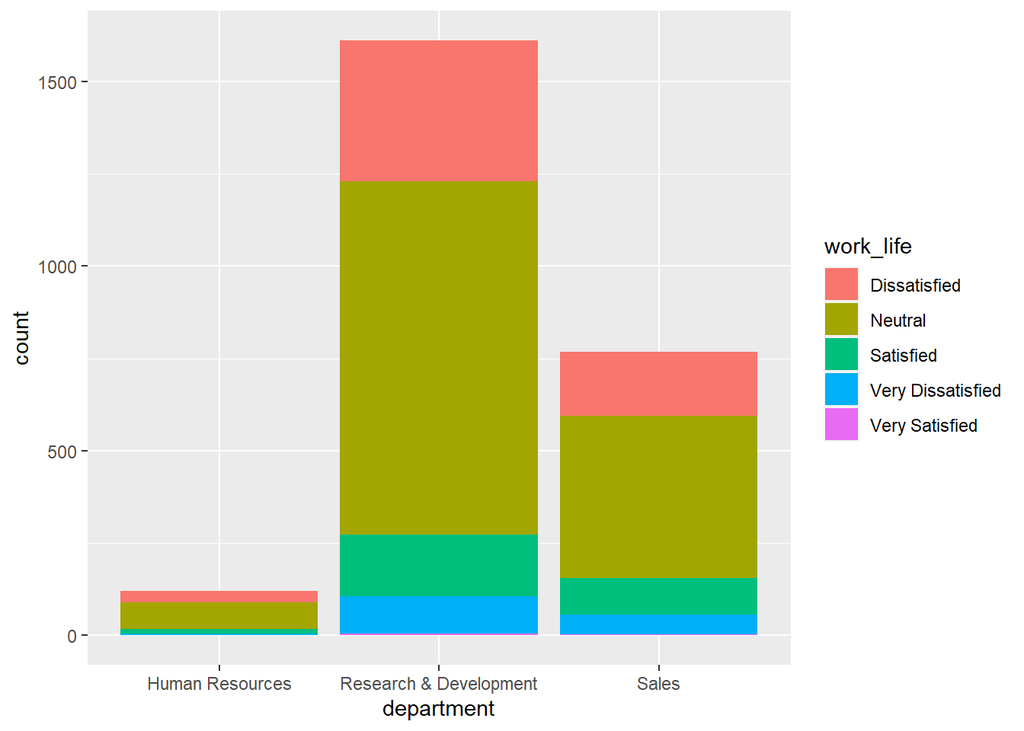

```r
ggplot(satisfaction,
       aes(x = department)) +
  geom_bar(aes(fill = work_life),
           stat = "count",
           position = "stack")
```

Version 4: 100% stacked bar chart. Set `position = "fill"`

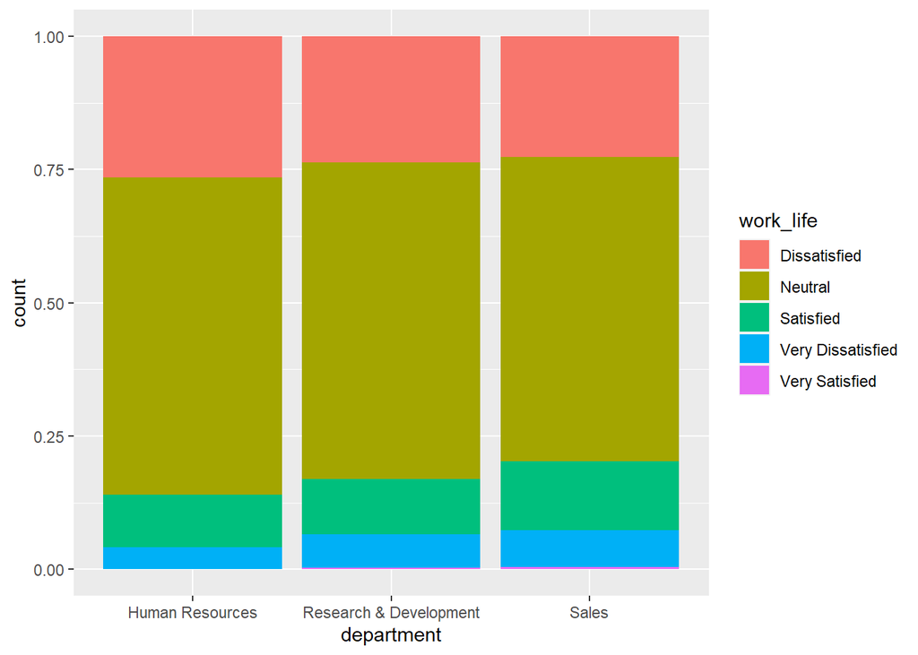

```r
ggplot(satisfaction,
       aes(x = department)) +
  geom_bar(aes(fill = work_life),
           stat = "count",
           position = "fill")
```

**Version** **5**: flipped coordinates

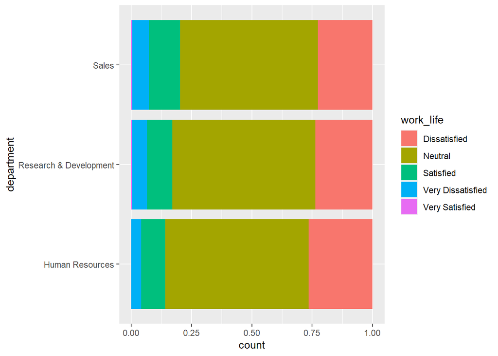

```r
ggplot(satisfaction,
       aes(x = department)) +
  geom_bar(aes(fill = work_life),
           stat = "count",
           position = "fill") +
  coord_flip()
```

## Sources

- https://ggplot2.tidyverse.org/
- https://info201.github.io/ggplot2.html
- https://www.youtube.com/watch?v=HPJn1CMvtmI